# Bonus2: Build a Supervised Autoencoder.

### Name: Zhili Yu

PCA and the standard autoencoder are unsupervised dimensionality reduction methods, and their learned features are not discriminative. If you build a classifier upon the low-dimenional features extracted by PCA and autoencoder, you will find the classification accuracy very poor.

Linear discriminant analysis (LDA) is a traditionally supervised dimensionality reduction method for learning low-dimensional features which are highly discriminative. Likewise, can we extend autoencoder to supervised leanring?

**You are required to build and train a supervised autoencoder look like the following.** You are required to add other layers properly to alleviate overfitting.

[figure not shown]

## 0. You will do the following:

1. Read and run my code to train a standard dense autoencoder.
2. Build and train a supervised autoencoder, visual the low-dim features and the reconstructions, and evaluate whether the learned low-dim features are discriminative.
3. Convert the .IPYNB file to .HTML file.
   - The HTML file must contain the code and the output after execution.
1. Upload this .HTML file to your Google Drive, Dropbox, or Github repo.
2. Submit the link to this .HTML file to Canvas.
   - Example: https://github.com/wangshusen/CS583-2020S/blob/master/homework/Bonus2/Bonus2.html

## 1. Data preparation

### 1.1. Load data

```python
from keras.datasets import mnist

(x_train, y_train), (x_test, y_test) = mnist.load_data()
x_train = x_train.reshape(60000, 28*28).astype('float32') / 255.
x_test = x_test.reshape(10000, 28*28).astype('float32') / 255.

print('Shape of x_train: ' + str(x_train.shape))
print('Shape of x_test: ' + str(x_test.shape))
print('Shape of y_train: ' + str(y_train.shape))
print('Shape of y_test: ' + str(y_test.shape))
```

```
Shape of x_train: (60000, 784)
Shape of x_test: (10000, 784)
Shape of y_train: (60000,)
Shape of y_test: (10000,)
```

### 1.2. One-hot encode the labels

In the input, a label is a scalar in $\{0, 1, \cdots , 9\}$. One-hot encode transform such a scalar to a $10$-dim vector. E.g., a scalar `y_train[j]=3` is transformed to the vector `y_train_vec[j]=[0, 0, 0, 1, 0, 0, 0, 0, 0, 0]`.

1. Define a function `to_one_hot` that transforms an $n\times 1$ array to a $n\times 10$ matrix.
2. Apply the function to `y_train` and `y_test`.

```python
import numpy

def to_one_hot(y, num_class=10):
    results = numpy.zeros((len(y), num_class))
    for i, label in enumerate(y):
        results[i, label] = 1.
    return results

y_train_vec = to_one_hot(y_train)
y_test_vec = to_one_hot(y_test)

print('Shape of y_train_vec: ' + str(y_train_vec.shape))
print('Shape of y_test_vec: ' + str(y_test_vec.shape))

print(y_train[0])
print(y_train_vec[0])
```

```
Shape of y_train_vec: (60000, 10)
Shape of y_test_vec: (10000, 10)
5
[0. 0. 0. 0. 0. 1. 0. 0. 0. 0.]
```

### 1.3. Randomly partition the training set to training and validation sets

Randomly partition the 60K training samples to 2 sets:

```python
rand_indices = numpy.random.permutation(60000)
train_indices = rand_indices[0:10000]
valid_indices = rand_indices[10000:20000]

x_val = x_train[valid_indices, :]
y_val = y_train_vec[valid_indices, :]

x_tr = x_train[train_indices, :]
y_tr = y_train_vec[train_indices, :]

print('Shape of x_tr: ' + str(x_tr.shape))
print('Shape of y_tr: ' + str(y_tr.shape))
print('Shape of x_val: ' + str(x_val.shape))
print('Shape of y_val: ' + str(y_val.shape))
```

```
Shape of x_tr: (10000, 784)
Shape of y_tr: (10000, 10)
Shape of x_val: (10000, 784)
Shape of y_val: (10000, 10)
```

## 2. Build an unsupervised autoencoder and tune its hyper-parameters

1. Build a dense autoencoder model
2. Use the validation data to tune the hyper-parameters (e.g., network structure, and optimization algorithm)
   - Do NOT use test data for hyper-parameter tuning!!!
3. Try to achieve a validation loss as low as possible.
4. Evaluate the model on the test set.
5. Visualize the low-dim features and reconstructions.

### 2.1. Build the model

```python
l2 = 0.08

from keras.layers import Dense, Input, BatchNormalization, Activation
from keras import models, regularizers

input_img = Input(shape=(784,), name='input_img')

encode1 = Dense(128, name='encode1',kernel_regularizer=regularizers.l2(l2))(input_img)
encode1 = BatchNormalization(axis=1)(encode1)
encode1 = Activation('relu')(encode1)
encode2 = Dense(32, name='encode2',kernel_regularizer=regularizers.l2(l2))(encode1)
encode2 = BatchNormalization(axis=1)(encode2)
encode2 = Activation('relu')(encode2)
encode3 = Dense(8, name='encode3',kernel_regularizer=regularizers.l2(l2))(encode2)
encode3 = BatchNormalization(axis=1)(encode3)
encode3 = Activation('relu')(encode3)
bottleneck = Dense(2, name='bottleneck',kernel_regularizer=regularizers.l2(l2))(encode3)
bottleneck = BatchNormalization(axis=1)(bottleneck)
bottleneck = Activation('relu')(bottleneck)
decode1 = Dense(8, name='decode1',kernel_regularizer=regularizers.l2(l2))(bottleneck)
decode1 = BatchNormalization(axis=1)(decode1)
decode1 = Activation('relu')(decode1)
decode2 = Dense(32, name='decode2',kernel_regularizer=regularizers.l2(l2))(decode1)
decode2 = BatchNormalization(axis=1)(decode2)
decode2 = Activation('relu')(decode2)
decode3 = Dense(128, name='decode3',kernel_regularizer=regularizers.l2(l2))(decode2)
decode3 = BatchNormalization(axis=1)(decode3)
decode3 = Activation('relu')(decode3)
decode4 = Dense(784, activation='relu', name='decode4',kernel_regularizer=regularizers.l2(l2))(decode3)

ae = models.Model(input_img, decode4)

ae.summary()
```

```
Model: "model_6"
_________________________________________________________________
Layer (type)                 Output Shape              Param #
=================================================================
input_img (InputLayer)       (None, 784)               0
_________________________________________________________________
encode1 (Dense)              (None, 128)               100480
_________________________________________________________________
batch_normalization_37 (Batc (None, 128)               512
_________________________________________________________________
activation_36 (Activation)   (None, 128)               0
_________________________________________________________________
encode2 (Dense)              (None, 32)                4128
_________________________________________________________________
batch_normalization_38 (Batc (None, 32)                128
_________________________________________________________________
activation_37 (Activation)   (None, 32)                0
_________________________________________________________________
encode3 (Dense)              (None, 8)                 264
_________________________________________________________________
batch_normalization_39 (Batc (None, 8)                 32
_________________________________________________________________
activation_38 (Activation)   (None, 8)                 0
_________________________________________________________________
bottleneck (Dense)           (None, 2)                 18
_________________________________________________________________
batch_normalization_40 (Batc (None, 2)                 8
_________________________________________________________________
activation_39 (Activation)   (None, 2)                 0
_________________________________________________________________
decode1 (Dense)              (None, 8)                 24
_________________________________________________________________
batch_normalization_41 (Batc (None, 8)                 32
_________________________________________________________________
activation_40 (Activation)   (None, 8)                 0
_________________________________________________________________
decode2 (Dense)              (None, 32)                288
_________________________________________________________________
batch_normalization_42 (Batc (None, 32)                128
_________________________________________________________________
activation_41 (Activation)   (None, 32)                0
_________________________________________________________________
decode3 (Dense)              (None, 128)               4224
_________________________________________________________________
batch_normalization_43 (Batc (None, 128)               512
_________________________________________________________________
activation_42 (Activation)   (None, 128)               0
_________________________________________________________________
decode4 (Dense)              (None, 784)               101136
=================================================================
Total params: 211,914
Trainable params: 211,238
Non-trainable params: 676
_________________________________________________________________
```

```python
# print the network structure to a PDF file

from IPython.display import SVG
from keras.utils.vis_utils import model_to_dot, plot_model

SVG(model_to_dot(ae, show_shapes=False).create(prog='dot', format='svg'))

plot_model(
    model=ae, show_shapes=False,
    to_file='unsupervised_ae.pdf'
)

# you can find the file "unsupervised_ae.pdf" in the current directory.
```

### 2.2. Train the model and tune the hyper-parameters

```python
from keras import optimizers

learning_rate = 1E-3 # to be tuned!

ae.compile(loss='mean_squared_error',
           optimizer=optimizers.RMSprop(lr=learning_rate))
```

```python
history = ae.fit(x_tr, x_tr,
                 batch_size=128,
                 epochs=50,
                 validation_data=(x_val, x_val),
                 verbose=2)
```

```
Train on 10000 samples, validate on 10000 samples
 - 2s - loss: 13.4519 - val_loss: 3.0566
 - 1s - loss: 1.6665 - val_loss: 0.8221
 - 1s - loss: 0.5343 - val_loss: 0.3537
 - 1s - loss: 0.2515 - val_loss: 0.1957
 - 1s - loss: 0.1471 - val_loss: 0.1239
 - 1s - loss: 0.1089 - val_loss: 0.0998
 - 1s - loss: 0.0889 - val_loss: 0.0821
 - 1s - loss: 0.0779 - val_loss: 0.0749
 - 1s - loss: 0.0732 - val_loss: 0.0723
 - 1s - loss: 0.0718 - val_loss: 0.0719
 - 1s - loss: 0.0717 - val_loss: 0.0718
 - 1s - loss: 0.0717 - val_loss: 0.0719
 - 1s - loss: 0.0717 - val_loss: 0.0719
 - 1s - loss: 0.0717 - val_loss: 0.0718
 - 1s - loss: 0.0717 - val_loss: 0.0718
 - 1s - loss: 0.0717 - val_loss: 0.0718
 - 1s - loss: 0.0717 - val_loss: 0.0718
 - 1s - loss: 0.0717 - val_loss: 0.0718
 - 1s - loss: 0.0717 - val_loss: 0.0718
 - 1s - loss: 0.0717 - val_loss: 0.0718
 - 1s - loss: 0.0717 - val_loss: 0.0719
 - 1s - loss: 0.0717 - val_loss: 0.0718
 - 1s - loss: 0.0717 - val_loss: 0.0719
 - 1s - loss: 0.0717 - val_loss: 0.0718
 - 1s - loss: 0.0717 - val_loss: 0.0718
 - 1s - loss: 0.0717 - val_loss: 0.0718
 - 1s - loss: 0.0717 - val_loss: 0.0718
 - 1s - loss: 0.0717 - val_loss: 0.0718
 - 1s - loss: 0.0717 - val_loss: 0.0718
 - 1s - loss: 0.0717 - val_loss: 0.0718
 - 1s - loss: 0.0717 - val_loss: 0.0718
 - 1s - loss: 0.0717 - val_loss: 0.0718
 - 1s - loss: 0.0717 - val_loss: 0.0718
 - 1s - loss: 0.0717 - val_loss: 0.0718
 - 1s - loss: 0.0717 - val_loss: 0.0718
 - 1s - loss: 0.0717 - val_loss: 0.0718
 - 1s - loss: 0.0717 - val_loss: 0.0718
 - 1s - loss: 0.0717 - val_loss: 0.0718
 - 1s - loss: 0.0717 - val_loss: 0.0718
 - 1s - loss: 0.0717 - val_loss: 0.0718
 - 1s - loss: 0.0717 - val_loss: 0.0718
 - 1s - loss: 0.0717 - val_loss: 0.0718
 - 1s - loss: 0.0717 - val_loss: 0.0718
 - 1s - loss: 0.0717 - val_loss: 0.0718
 - 1s - loss: 0.0717 - val_loss: 0.0718
 - 1s - loss: 0.0717 - val_loss: 0.0718
 - 1s - loss: 0.0717 - val_loss: 0.0718
 - 1s - loss: 0.0717 - val_loss: 0.0718
 - 1s - loss: 0.0717 - val_loss: 0.0718
 - 1s - loss: 0.0717 - val_loss: 0.0718
```

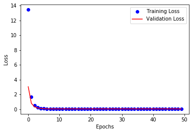

```python
import matplotlib.pyplot as plt
%matplotlib inline

loss = history.history['loss']
val_loss = history.history['val_loss']

epochs = range(len(loss))

plt.plot(epochs, loss, 'bo', label='Training Loss')
plt.plot(epochs, val_loss, 'r', label='Validation Loss')
plt.xlabel('Epochs')
plt.ylabel('Loss')
plt.legend()
plt.show()
```

### 2.3. Visualize the reconstructed test images

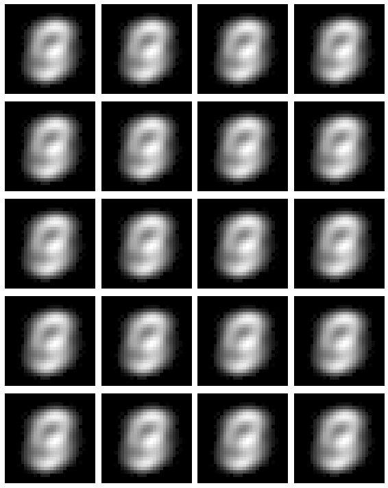

```python
ae_output = ae.predict(x_test).reshape((10000, 28, 28))

ROW = 5
COLUMN = 4

x = ae_output
fname = 'reconstruct_ae.pdf'

fig, axes = plt.subplots(nrows=ROW, ncols=COLUMN, figsize=(8, 10))
for ax, i in zip(axes.flat, numpy.arange(ROW*COLUMN)):
    image = x[i].reshape(28, 28)
    ax.imshow(image, cmap='gray')
    ax.axis('off')

plt.tight_layout()
plt.savefig(fname)
plt.show()
```

### 2.4. Evaluate the model on the test set

Do NOT used the test set until now. Make sure that your model parameters and hyper-parameters are independent of the test set.

```python
loss = ae.evaluate(x_test, x_test)
print('loss = ' + str(loss))
```

```
loss = 0.07174831858873368
```

### 2.5. Visualize the low-dimensional features

```python
# build the encoder network
ae_encoder = models.Model(input_img, bottleneck)
ae_encoder.summary()
```

```
Model: "model_7"
_________________________________________________________________
Layer (type)                 Output Shape              Param #
=================================================================
input_img (InputLayer)       (None, 784)               0
_________________________________________________________________
encode1 (Dense)              (None, 128)               100480
_________________________________________________________________
batch_normalization_37 (Batc (None, 128)               512
_________________________________________________________________
activation_36 (Activation)   (None, 128)               0
_________________________________________________________________
encode2 (Dense)              (None, 32)                4128
_________________________________________________________________
batch_normalization_38 (Batc (None, 32)                128
_________________________________________________________________
activation_37 (Activation)   (None, 32)                0
_________________________________________________________________
encode3 (Dense)              (None, 8)                 264
_________________________________________________________________
batch_normalization_39 (Batc (None, 8)                 32
_________________________________________________________________
activation_38 (Activation)   (None, 8)                 0
_________________________________________________________________
bottleneck (Dense)           (None, 2)                 18
_________________________________________________________________
batch_normalization_40 (Batc (None, 2)                 8
_________________________________________________________________
activation_39 (Activation)   (None, 2)                 0
=================================================================
Total params: 105,570
Trainable params: 105,230
Non-trainable params: 340
_________________________________________________________________
```

```python
# extract low-dimensional features from the test data
encoded_test = ae_encoder.predict(x_test)
print('Shape of encoded_test: ' + str(encoded_test.shape))
```

```
Shape of encoded_test: (10000, 2)
```

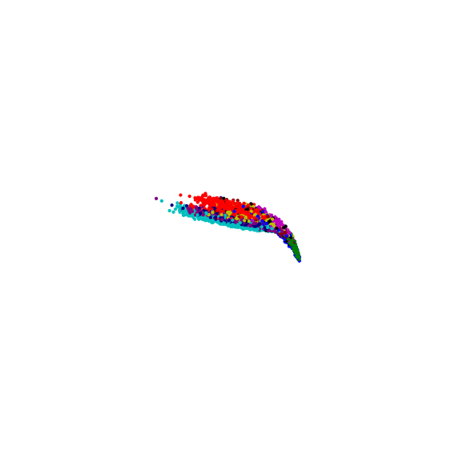

```python
colors = numpy.array(['r', 'g', 'b', 'm', 'c', 'k', 'y', 'purple', 'darkred', 'navy'])
colors_test = colors[y_test]


import matplotlib.pyplot as plt
%matplotlib inline

fig = plt.figure(figsize=(8, 8))
plt.scatter(encoded_test[:, 0], encoded_test[:, 1], s=10, c=colors_test, edgecolors=colors_test)
plt.axis('off')
plt.tight_layout()
fname = 'ae_code.pdf'
plt.savefig(fname)
```

#### Remark:

Judging from the visualization, the low-dim features seems not discriminative, as 2D features from different classes are mixed. Let quantatively find out whether they are discriminative.

## 3. Are the learned low-dim features discriminative?

To find the answer, lets train a classifier on the training set (the extracted 2-dim features) and evaluation on the test set.

```python
# extract the 2D features from the training, validation, and test samples
f_tr = ae_encoder.predict(x_tr)
f_val = ae_encoder.predict(x_val)
f_te = ae_encoder.predict(x_test)

print('Shape of f_tr: ' + str(f_tr.shape))
print('Shape of f_te: ' + str(f_te.shape))
```

```
Shape of f_tr: (10000, 2)
Shape of f_te: (10000, 2)
```

```python
from keras.layers import Dense, Input
from keras import models

input_feat = Input(shape=(2,))

hidden1 = Dense(128, activation='relu')(input_feat)
hidden2 = Dense(128, activation='relu')(hidden1)
output = Dense(10, activation='softmax')(hidden2)

classifier = models.Model(input_feat, output)

classifier.summary()
```

```
Model: "model_8"
_________________________________________________________________
Layer (type)                 Output Shape              Param #
=================================================================
input_1 (InputLayer)         (None, 2)                 0
_________________________________________________________________
dense_1 (Dense)              (None, 128)               384
_________________________________________________________________
dense_2 (Dense)              (None, 128)               16512
_________________________________________________________________
dense_3 (Dense)              (None, 10)                1290
=================================================================
Total params: 18,186
Trainable params: 18,186
Non-trainable params: 0
_________________________________________________________________
```

```python
classifier.compile(loss='categorical_crossentropy',
                  optimizer=optimizers.RMSprop(lr=1E-4),
                  metrics=['acc'])

history = classifier.fit(f_tr, y_tr,
                        batch_size=32,
                        epochs=30,
                        validation_data=(f_val, y_val))
```

[output not shown]

```
Train on 10000 samples, validate on 10000 samples
```

### Conclusion

Using the 2D features, the validation accuracy is 60~70%. Recall that using the original data, the accuracy is about 98%. Obviously, the 2D features are not very discriminative.

We are going to build a supervised autoencode model for learning low-dimensional discriminative features.

## 4. Build a supervised autoencoder model

**You are required to build and train a supervised autoencoder look like the following.** (Not necessary the same.) You are required to add other layers properly to alleviate overfitting.

[figure not shown]

### 4.1. Build the network

```python
l2 = 0.01
# build the supervised autoencoder network
from keras.layers import Dense, Input
from keras import models

input_img = Input(shape=(784,), name='input_img')

#encoder net
encode1 = Dense(128, name='encode1',kernel_regularizer=regularizers.l2(l2))(input_img)
encode1 = BatchNormalization(axis=1)(encode1)
encode1 = Activation('relu')(encode1)
encode2 = Dense(32, name='encode2',kernel_regularizer=regularizers.l2(l2))(encode1)
encode2 = BatchNormalization(axis=1)(encode2)
encode2 = Activation('relu')(encode2)
encode3 = Dense(8, name='encode3',kernel_regularizer=regularizers.l2(l2))(encode2)
encode3 = BatchNormalization(axis=1)(encode3)
encode3 = Activation('relu')(encode3)
bottleneck = Dense(2, name='bottleneck',kernel_regularizer=regularizers.l2(l2))(encode3)
bottleneck = BatchNormalization(axis=1)(bottleneck)
bottleneck = Activation('relu')(bottleneck)

#decoder net
decode1 = Dense(8, name='decode1',kernel_regularizer=regularizers.l2(l2))(bottleneck)
decode1 = BatchNormalization(axis=1)(decode1)
decode1 = Activation('relu')(decode1)
decode2 = Dense(32, name='decode2',kernel_regularizer=regularizers.l2(l2))(decode1)
decode2 = BatchNormalization(axis=1)(decode2)
decode2 = Activation('relu')(decode2)
decode3 = Dense(128, name='decode3',kernel_regularizer=regularizers.l2(l2))(decode2)
decode3 = BatchNormalization(axis=1)(decode3)
decode3 = Activation('relu')(decode3)
decode4 = Dense(784, activation='relu', name='decode4',kernel_regularizer=regularizers.l2(l2))(decode3)


# build a classifier upon the bottleneck layer
classifier1 = Dense(128, name='classifier1',kernel_regularizer=regularizers.l2(l2))(bottleneck)
classifier1 = BatchNormalization(axis=1)(classifier1)
classifier1 = Activation('relu')(classifier1)
classifier2 = Dense(128, name='classifier2',kernel_regularizer=regularizers.l2(l2))(classifier1)
classifier2 = BatchNormalization(axis=1)(classifier2)
classifier2 = Activation('relu')(classifier2)
classifier3 = Dense(10, activation='softmax', name='classifier3',kernel_regularizer=regularizers.l2(l2))(classifier2)
```

```python
# connect the input and the two outputs
sae = models.Model(input_img, [decode4, classifier3])

sae.summary()
```

```
Model: "model_16"
__________________________________________________________________________________________________
Layer (type)                    Output Shape         Param #     Connected to
==================================================================================================
input_img (InputLayer)          (None, 784)          0
__________________________________________________________________________________________________
encode1 (Dense)                 (None, 128)          100480      input_img[0][0]
__________________________________________________________________________________________________
batch_normalization_62 (BatchNo (None, 128)          512         encode1[0][0]
__________________________________________________________________________________________________
activation_61 (Activation)      (None, 128)          0           batch_normalization_62[0][0]
__________________________________________________________________________________________________
encode2 (Dense)                 (None, 32)           4128        activation_61[0][0]
__________________________________________________________________________________________________
batch_normalization_63 (BatchNo (None, 32)           128         encode2[0][0]
__________________________________________________________________________________________________
activation_62 (Activation)      (None, 32)           0           batch_normalization_63[0][0]
__________________________________________________________________________________________________
encode3 (Dense)                 (None, 8)            264         activation_62[0][0]
__________________________________________________________________________________________________
batch_normalization_64 (BatchNo (None, 8)            32          encode3[0][0]
__________________________________________________________________________________________________
activation_63 (Activation)      (None, 8)            0           batch_normalization_64[0][0]
__________________________________________________________________________________________________
bottleneck (Dense)              (None, 2)            18          activation_63[0][0]
__________________________________________________________________________________________________
batch_normalization_65 (BatchNo (None, 2)            8           bottleneck[0][0]
__________________________________________________________________________________________________
activation_64 (Activation)      (None, 2)            0           batch_normalization_65[0][0]
__________________________________________________________________________________________________
decode1 (Dense)                 (None, 8)            24          activation_64[0][0]
__________________________________________________________________________________________________
batch_normalization_66 (BatchNo (None, 8)            32          decode1[0][0]
__________________________________________________________________________________________________
activation_65 (Activation)      (None, 8)            0           batch_normalization_66[0][0]
__________________________________________________________________________________________________
decode2 (Dense)                 (None, 32)           288         activation_65[0][0]
__________________________________________________________________________________________________
classifier1 (Dense)             (None, 128)          384         activation_64[0][0]
__________________________________________________________________________________________________
```

[output cut: 13 more lines]

```
__________________________________________________________________________________________________
batch_normalization_70 (BatchNo (None, 128)          512         classifier2[0][0]
__________________________________________________________________________________________________
activation_67 (Activation)      (None, 128)          0           batch_normalization_68[0][0]
__________________________________________________________________________________________________
activation_69 (Activation)      (None, 128)          0           batch_normalization_70[0][0]
__________________________________________________________________________________________________
decode4 (Dense)                 (None, 784)          101136      activation_67[0][0]
__________________________________________________________________________________________________
classifier3 (Dense)             (None, 10)           1290        activation_69[0][0]
==================================================================================================
Total params: 231,124
Trainable params: 229,936
Non-trainable params: 1,188
__________________________________________________________________________________________________
```

```python
# print the network structure to a PDF file

from IPython.display import SVG
from keras.utils.vis_utils import model_to_dot, plot_model

SVG(model_to_dot(sae, show_shapes=False).create(prog='dot', format='svg'))

plot_model(
    model=sae, show_shapes=False,
    to_file='supervised_ae.pdf'
)

# you can find the file "supervised_ae.pdf" in the current directory.
```

### 4.2. Train the new model and tune the hyper-parameters

The new model has multiple output. Thus we specify **multiple** loss functions and their weights.

```python
from keras import optimizers

sae.compile(loss=['mean_squared_error', 'categorical_crossentropy'],
            loss_weights=[1, 0.5], # to be tuned
            optimizer=optimizers.RMSprop(lr=1E-3))

history = sae.fit(x_tr, [x_tr, y_tr],
                  batch_size=32,
                  epochs=50,
                  validation_data=(x_val, [x_val, y_val]),
                  verbose=2)
```

```
Train on 10000 samples, validate on 10000 samples
 - 5s - loss: 2.7743 - decode4_loss: 0.0676 - classifier3_loss: 1.2582 - val_loss: 2.1845 - val_decode4_loss: 0.0713 - val_classifier3_loss: 2.3545
 - 4s - loss: 1.1691 - decode4_loss: 0.0607 - classifier3_loss: 0.8984 - val_loss: 1.1255 - val_decode4_loss: 0.0649 - val_classifier3_loss: 1.1686
 - 4s - loss: 0.8476 - decode4_loss: 0.0596 - classifier3_loss: 0.7809 - val_loss: 0.8439 - val_decode4_loss: 0.0611 - val_classifier3_loss: 0.8801
 - 4s - loss: 0.7390 - decode4_loss: 0.0592 - classifier3_loss: 0.7379 - val_loss: 0.6500 - val_decode4_loss: 0.0599 - val_classifier3_loss: 0.6075
 - 4s - loss: 0.6855 - decode4_loss: 0.0589 - classifier3_loss: 0.7165 - val_loss: 0.6033 - val_decode4_loss: 0.0596 - val_classifier3_loss: 0.5789
 - 4s - loss: 0.6437 - decode4_loss: 0.0586 - classifier3_loss: 0.6791 - val_loss: 0.5901 - val_decode4_loss: 0.0585 - val_classifier3_loss: 0.5862
 - 4s - loss: 0.6307 - decode4_loss: 0.0585 - classifier3_loss: 0.6770 - val_loss: 0.6097 - val_decode4_loss: 0.0580 - val_classifier3_loss: 0.6444
 - 4s - loss: 0.6004 - decode4_loss: 0.0581 - classifier3_loss: 0.6356 - val_loss: 0.6287 - val_decode4_loss: 0.0582 - val_classifier3_loss: 0.7000
 - 4s - loss: 0.5742 - decode4_loss: 0.0580 - classifier3_loss: 0.6014 - val_loss: 0.6217 - val_decode4_loss: 0.0600 - val_classifier3_loss: 0.6945
 - 4s - loss: 0.5773 - decode4_loss: 0.0580 - classifier3_loss: 0.6135 - val_loss: 0.5519 - val_decode4_loss: 0.0588 - val_classifier3_loss: 0.5628
 - 4s - loss: 0.5468 - decode4_loss: 0.0577 - classifier3_loss: 0.5627 - val_loss: 0.5529 - val_decode4_loss: 0.0594 - val_classifier3_loss: 0.5720
 - 4s - loss: 0.5354 - decode4_loss: 0.0576 - classifier3_loss: 0.5496 - val_loss: 0.4921 - val_decode4_loss: 0.0594 - val_classifier3_loss: 0.4662
 - 4s - loss: 0.5358 - decode4_loss: 0.0576 - classifier3_loss: 0.5552 - val_loss: 0.5028 - val_decode4_loss: 0.0578 - val_classifier3_loss: 0.4928
 - 4s - loss: 0.5264 - decode4_loss: 0.0575 - classifier3_loss: 0.5440 - val_loss: 0.5524 - val_decode4_loss: 0.0574 - val_classifier3_loss: 0.5960
 - 4s - loss: 0.5181 - decode4_loss: 0.0573 - classifier3_loss: 0.5315 - val_loss: 0.5059 - val_decode4_loss: 0.0581 - val_classifier3_loss: 0.5064
 - 4s - loss: 0.5226 - decode4_loss: 0.0574 - classifier3_loss: 0.5400 - val_loss: 0.4643 - val_decode4_loss: 0.0579 - val_classifier3_loss: 0.4227
 - 4s - loss: 0.5160 - decode4_loss: 0.0572 - classifier3_loss: 0.5318 - val_loss: 0.4897 - val_decode4_loss: 0.0576 - val_classifier3_loss: 0.4823
 - 4s - loss: 0.5126 - decode4_loss: 0.0571 - classifier3_loss: 0.5331 - val_loss: 0.4506 - val_decode4_loss: 0.0585 - val_classifier3_loss: 0.4119
 - 4s - loss: 0.5024 - decode4_loss: 0.0570 - classifier3_loss: 0.5165 - val_loss: 0.5594 - val_decode4_loss: 0.0571 - val_classifier3_loss: 0.6274
 - 4s - loss: 0.4933 - decode4_loss: 0.0568 - classifier3_loss: 0.5010 - val_loss: 0.4443 - val_decode4_loss: 0.0569 - val_classifier3_loss: 0.4100
 - 4s - loss: 0.4872 - decode4_loss: 0.0567 - classifier3_loss: 0.4970 - val_loss: 0.4542 - val_decode4_loss: 0.0579 - val_classifier3_loss: 0.4303
 - 4s - loss: 0.4870 - decode4_loss: 0.0567 - classifier3_loss: 0.4975 - val_loss: 0.5058 - val_decode4_loss: 0.0568 - val_classifier3_loss: 0.5355
 - 4s - loss: 0.4934 - decode4_loss: 0.0567 - classifier3_loss: 0.5148 - val_loss: 0.4296 - val_decode4_loss: 0.0563 - val_classifier3_loss: 0.3866
 - 4s - loss: 0.4792 - decode4_loss: 0.0565 - classifier3_loss: 0.4875 - val_loss: 0.4346 - val_decode4_loss: 0.0556 - val_classifier3_loss: 0.3992
 - 4s - loss: 0.4767 - decode4_loss: 0.0565 - classifier3_loss: 0.4869 - val_loss: 0.4482 - val_decode4_loss: 0.0585 - val_classifier3_loss: 0.4286
 - 4s - loss: 0.4718 - decode4_loss: 0.0566 - classifier3_loss: 0.4842 - val_loss: 0.4846 - val_decode4_loss: 0.0578 - val_classifier3_loss: 0.5089
 - 4s - loss: 0.4691 - decode4_loss: 0.0566 - classifier3_loss: 0.4818 - val_loss: 0.4643 - val_decode4_loss: 0.0578 - val_classifier3_loss: 0.4728
 - 4s - loss: 0.4722 - decode4_loss: 0.0565 - classifier3_loss: 0.4928 - val_loss: 0.3969 - val_decode4_loss: 0.0574 - val_classifier3_loss: 0.3409
 - 4s - loss: 0.4665 - decode4_loss: 0.0565 - classifier3_loss: 0.4874 - val_loss: 0.4802 - val_decode4_loss: 0.0566 - val_classifier3_loss: 0.5143
 - 4s - loss: 0.4637 - decode4_loss: 0.0565 - classifier3_loss: 0.4840 - val_loss: 0.4246 - val_decode4_loss: 0.0568 - val_classifier3_loss: 0.4034
 - 4s - loss: 0.4554 - decode4_loss: 0.0563 - classifier3_loss: 0.4692 - val_loss: 0.4175 - val_decode4_loss: 0.0559 - val_classifier3_loss: 0.3931
 - 4s - loss: 0.4497 - decode4_loss: 0.0563 - classifier3_loss: 0.4615 - val_loss: 0.4452 - val_decode4_loss: 0.0565 - val_classifier3_loss: 0.4538
 - 4s - loss: 0.4487 - decode4_loss: 0.0563 - classifier3_loss: 0.4629 - val_loss: 0.4220 - val_decode4_loss: 0.0563 - val_classifier3_loss: 0.4171
```

[output cut: 17 more lines]

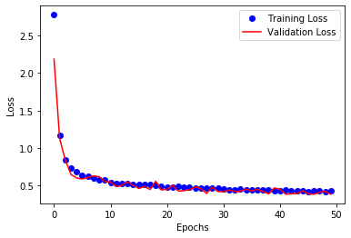

```python
import matplotlib.pyplot as plt
%matplotlib inline

loss = history.history['loss']
val_loss = history.history['val_loss']

epochs = range(len(loss))

plt.plot(epochs, loss, 'bo', label='Training Loss')
plt.plot(epochs, val_loss, 'r', label='Validation Loss')
plt.xlabel('Epochs')
plt.ylabel('Loss')
plt.legend()
plt.show()
```

### Question

Do you think overfitting is happening? If yes, what can you do? Please make necessary changes to the supervised autoencoder network structure.

**Failing to add proper regularization will lose 1~2 scores.**

### 4.3. Visualize the reconstructed test images

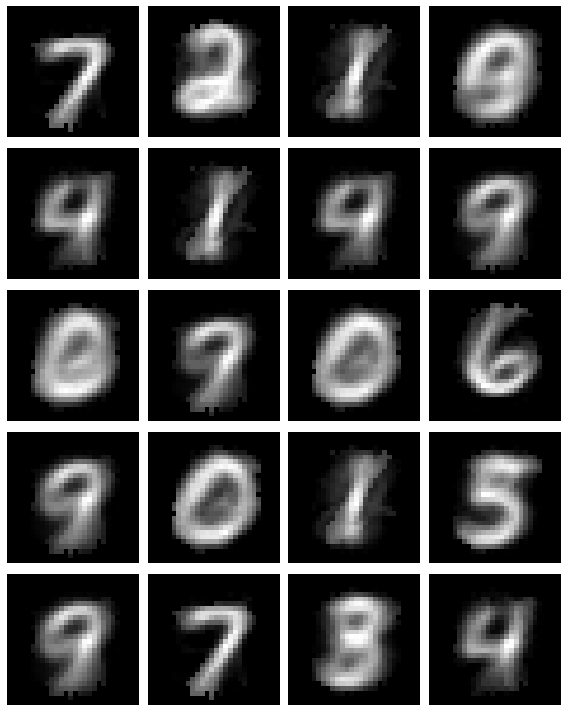

```python
sae_output = sae.predict(x_test)[0].reshape((10000, 28, 28))

ROW = 5
COLUMN = 4

x = sae_output
fname = 'reconstruct_sae.pdf'

fig, axes = plt.subplots(nrows=ROW, ncols=COLUMN, figsize=(8, 10))
for ax, i in zip(axes.flat, numpy.arange(ROW*COLUMN)):
    image = x[i].reshape(28, 28)
    ax.imshow(image, cmap='gray')
    ax.axis('off')

plt.tight_layout()
plt.savefig(fname)
plt.show()
```

### 4.4. Visualize the low-dimensional features

```python
# build the encoder model
sae_encoder = models.Model(input_img, bottleneck)
sae_encoder.summary()
```

```
Model: "model_17"
_________________________________________________________________
Layer (type)                 Output Shape              Param #
=================================================================
input_img (InputLayer)       (None, 784)               0
_________________________________________________________________
encode1 (Dense)              (None, 128)               100480
_________________________________________________________________
batch_normalization_62 (Batc (None, 128)               512
_________________________________________________________________
activation_61 (Activation)   (None, 128)               0
_________________________________________________________________
encode2 (Dense)              (None, 32)                4128
_________________________________________________________________
batch_normalization_63 (Batc (None, 32)                128
_________________________________________________________________
activation_62 (Activation)   (None, 32)                0
_________________________________________________________________
encode3 (Dense)              (None, 8)                 264
_________________________________________________________________
batch_normalization_64 (Batc (None, 8)                 32
_________________________________________________________________
activation_63 (Activation)   (None, 8)                 0
_________________________________________________________________
bottleneck (Dense)           (None, 2)                 18
_________________________________________________________________
batch_normalization_65 (Batc (None, 2)                 8
_________________________________________________________________
activation_64 (Activation)   (None, 2)                 0
=================================================================
Total params: 105,570
Trainable params: 105,230
Non-trainable params: 340
_________________________________________________________________
```

```
Shape of encoded_test: (10000, 2)
```

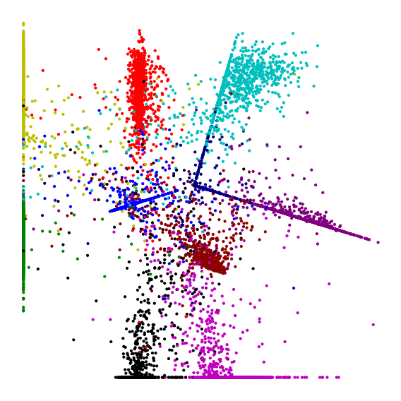

```python
# extract test features
encoded_test = sae_encoder.predict(x_test)
print('Shape of encoded_test: ' + str(encoded_test.shape))

colors = numpy.array(['r', 'g', 'b', 'm', 'c', 'k', 'y', 'purple', 'darkred', 'navy'])
colors_test = colors[y_test]


import matplotlib.pyplot as plt
%matplotlib inline

fig = plt.figure(figsize=(8, 8))
plt.scatter(encoded_test[:, 0], encoded_test[:, 1], s=10, c=colors_test, edgecolors=colors_test)
plt.axis('off')
plt.tight_layout()
fname = 'sae_code.pdf'
plt.savefig(fname)
```

### 4.5. Are the learned low-dim features discriminative?

To find the answer, lets train a classifier on the training set (the extracted 2-dim features) and evaluation on the test set.

```python
# extract 2D features from the training, validation, and test samples
f_tr = sae_encoder.predict(x_tr)
f_val = sae_encoder.predict(x_val)
f_te = sae_encoder.predict(x_test)
```

```python
# build a classifier which takes the 2D features as input
from keras.layers import Dense, Input
from keras import models

input_feat = Input(shape=(2,))

hidden1 = Dense(128, activation='relu')(input_feat)
hidden2 = Dense(128, activation='relu')(hidden1)
output = Dense(10, activation='softmax')(hidden2)

classifier = models.Model(input_feat, output)

classifier.summary()
```

```
Model: "model_18"
_________________________________________________________________
Layer (type)                 Output Shape              Param #
=================================================================
input_5 (InputLayer)         (None, 2)                 0
_________________________________________________________________
dense_13 (Dense)             (None, 128)               384
_________________________________________________________________
dense_14 (Dense)             (None, 128)               16512
_________________________________________________________________
dense_15 (Dense)             (None, 10)                1290
=================================================================
Total params: 18,186
Trainable params: 18,186
Non-trainable params: 0
_________________________________________________________________
```

```python
classifier.compile(loss='categorical_crossentropy',
                  optimizer=optimizers.RMSprop(lr=1E-4),
                  metrics=['acc'])

history = classifier.fit(f_tr, y_tr,
                        batch_size=32,
                        epochs=30,
                        validation_data=(f_val, y_val),
                         verbose=2)
```

```
Train on 10000 samples, validate on 10000 samples
 - 1s - loss: 2.1178 - acc: 0.3454 - val_loss: 1.9525 - val_acc: 0.4392
 - 1s - loss: 1.7573 - acc: 0.4640 - val_loss: 1.5836 - val_acc: 0.4647
 - 1s - loss: 1.4180 - acc: 0.4707 - val_loss: 1.3062 - val_acc: 0.4694
 - 1s - loss: 1.1836 - acc: 0.5129 - val_loss: 1.1281 - val_acc: 0.6480
 - 1s - loss: 1.0254 - acc: 0.6971 - val_loss: 1.0005 - val_acc: 0.7350
 - 1s - loss: 0.9028 - acc: 0.7587 - val_loss: 0.8938 - val_acc: 0.8255
 - 1s - loss: 0.7938 - acc: 0.8303 - val_loss: 0.7945 - val_acc: 0.8744
 - 1s - loss: 0.6942 - acc: 0.9058 - val_loss: 0.7060 - val_acc: 0.8936
 - 1s - loss: 0.6067 - acc: 0.9196 - val_loss: 0.6313 - val_acc: 0.9025
 - 1s - loss: 0.5351 - acc: 0.9240 - val_loss: 0.5737 - val_acc: 0.9049
 - 1s - loss: 0.4820 - acc: 0.9274 - val_loss: 0.5334 - val_acc: 0.9031
 - 1s - loss: 0.4428 - acc: 0.9274 - val_loss: 0.5026 - val_acc: 0.9078
 - 1s - loss: 0.4147 - acc: 0.9275 - val_loss: 0.4820 - val_acc: 0.9082
 - 1s - loss: 0.3942 - acc: 0.9284 - val_loss: 0.4666 - val_acc: 0.9084
 - 1s - loss: 0.3792 - acc: 0.9292 - val_loss: 0.4566 - val_acc: 0.9079
 - 1s - loss: 0.3680 - acc: 0.9291 - val_loss: 0.4483 - val_acc: 0.9084
 - 1s - loss: 0.3587 - acc: 0.9296 - val_loss: 0.4426 - val_acc: 0.9082
 - 1s - loss: 0.3516 - acc: 0.9300 - val_loss: 0.4361 - val_acc: 0.9086
 - 1s - loss: 0.3452 - acc: 0.9295 - val_loss: 0.4306 - val_acc: 0.9098
 - 1s - loss: 0.3395 - acc: 0.9304 - val_loss: 0.4266 - val_acc: 0.9090
 - 1s - loss: 0.3346 - acc: 0.9311 - val_loss: 0.4240 - val_acc: 0.9090
 - 1s - loss: 0.3306 - acc: 0.9299 - val_loss: 0.4189 - val_acc: 0.9110
 - 1s - loss: 0.3269 - acc: 0.9302 - val_loss: 0.4167 - val_acc: 0.9099
 - 1s - loss: 0.3233 - acc: 0.9307 - val_loss: 0.4142 - val_acc: 0.9108
 - 1s - loss: 0.3199 - acc: 0.9310 - val_loss: 0.4131 - val_acc: 0.9099
 - 1s - loss: 0.3172 - acc: 0.9310 - val_loss: 0.4085 - val_acc: 0.9110
 - 1s - loss: 0.3148 - acc: 0.9313 - val_loss: 0.4063 - val_acc: 0.9121
 - 1s - loss: 0.3121 - acc: 0.9316 - val_loss: 0.4051 - val_acc: 0.9118
 - 1s - loss: 0.3097 - acc: 0.9311 - val_loss: 0.4041 - val_acc: 0.9106
 - 1s - loss: 0.3080 - acc: 0.9308 - val_loss: 0.4019 - val_acc: 0.9112
```

#### Remark:

The validation accuracy must be above 90%. It means the low-dim features learned by the supervised autoencoder are very effective.